# HW2

## Problem 1

version 1

```r
#' @title A random walk using a for loop
#' @description This function simulates a 1-dimensional random walk
#' with specific rules, implemented using a for loop.
#' @param n The number of steps for the random walk.
#' @return The final position of the walk.
#' @examples
#' random_walk1(10)
#' random_walk1(100)
random_walk1 <- function(n) {
  position <- 0
  #'initial the first position
  for (i in 1:n) {
    first_choice <- sample(c(1, -1), 1, prob = c(0.5, 0.5))
    #' loop for n times
    if (first_choice == 1) {
      final_step <- ifelse(runif(1) < 0.05, 10, 1)
      #' situation for choosing 1
    } else {
      final_step <- ifelse(runif(1) < 0.20, -3, -1)
      #' situation for choosing -1
    }
    position <- position + final_step
    #' position after 1 loop
  }
  return(position)
}
```

version 2

```r
#' @title A random walk using vectorized functions
#' @description This function simulates a 1-dimensional random walk
#' using vectorized R functions for improved performance.
#' @param n The number of steps for the random walk.
#' @return The final position of the walk.
#' @examples
#' random_walk2(10)
#' random_walk2(100)
random_walk2 <- function(n) {
  #' Generate n initial moves (+1 or -1)
  steps <- sample(c(1, -1), n, replace = TRUE, prob = c(0.5, 0.5))

  #' Identify positions for special steps
  special_plus <- which(steps == 1 & runif(n) < 0.05)
  special_minus <- which(steps == -1 & runif(n) < 0.20)

  #' Replace the values for special steps
  steps[special_plus] <- 10
  steps[special_minus] <- -3

  #' Sum all the steps to get the final position
  return(sum(steps))
}
```

version3

```r
#' @title A random walk using the apply family
#' @description This function simulates a 1-dimensional random walk
#' by applying a single-step function over the number of steps.
#' @param n The number of steps for the random walk.
#' @return The final position of the walk.
#' @examples
#' random_walk3(10)
#' random_walk3(100)
random_walk3 <- function(n) {

  #' Helper function to compute a single step
  single_step <- function(x) {
    step_choice <- sample(c(1, -1), 1, prob = c(0.5, 0.5))
    if (step_choice == 1) {
      final_step <- ifelse(runif(1) < 0.05, 10, 1)
    } else {
      final_step <- ifelse(runif(1) < 0.20, -3, -1)
    }
    return(final_step)
  }

  #' Apply the single_step function n times and sum the results
  return(sum(sapply(1:n, single_step)))
}
```

```r
random_walk1(10)
```

```
[1] -2
```

```r
random_walk2(10)
```

```
[1] 0
```

```r
random_walk3(10)
```

```
[1] 2
```

```r
random_walk1(1000)
```

```
[1] -39
```

```r
random_walk2(1000)
```

```
[1] -30
```

```r
random_walk3(1000)
```

```
[1] 17
```

B

```r
set.seed(42)
pos1_10 <- random_walk1(10)
set.seed(42)
pos2_10 <- random_walk2(10)
set.seed(42)
pos3_10 <- random_walk3(10)
print(paste("random_walk1(10):", pos1_10))
```

```
[1] "random_walk1(10): 2"
```

```r
print(paste("random_walk2(10):", pos2_10))
```

```
[1] "random_walk2(10): 6"
```

```r
print(paste("random_walk3(10):", pos3_10))
```

```
[1] "random_walk3(10): 2"
```

```r
print(paste("Are they all the same? ", pos1_10 == pos2_10 && pos2_10 == pos3_10))
```

```
[1] "Are they all the same?  FALSE"
```

```r
set.seed(42)
pos1_1000 <- random_walk1(1000)
set.seed(42)
pos2_1000 <- random_walk2(1000)
set.seed(42)
pos3_1000 <- random_walk3(1000)
print(paste("random_walk1(1000):", pos1_1000))
```

```
[1] "random_walk1(1000): -11"
```

```r
print(paste("random_walk2(1000):", pos2_1000))
```

```
[1] "random_walk2(1000): 14"
```

```r
print(paste("random_walk3(1000):", pos3_1000))
```

```
[1] "random_walk3(1000): -11"
```

```r
print(paste("Are they all the same? ", pos1_1000 == pos2_1000 && pos2_1000 == pos3_1000))
```

```
[1] "Are they all the same?  FALSE"
```

Why this is different? I thought it may be because of the order. In version 1 and 3, the function uses the random by order, but in version 2 ,it will use the random in plus first , then is the minus, so it is different, if we need to make it same , we need to make some changes in version 2.

```r
#' @title A random walk using a purely vectorized approach
#' @description This version of the random walk uses vectorized functions
#' to produce a result that is identical to the loop-based versions
#' by pre-generating all required random numbers.
#' @param n The number of steps for the random walk.
#' @return The final position of the walk.
#' @examples
adjust_random_walk2 <- function(n) {
  all_random_numbers <- runif(2 * n)
  #' first, we get all the random number
  direction_choices <- all_random_numbers[seq(1, by = 2, length.out = n)]
  #' in version 1 and 2 we know that the sequence of consuming the random number is plus of minus first, then is the value.So , 1,3,5 is direction, 2, 4, 6is value
  move_choices <- all_random_numbers[seq(2, by = 2, length.out = n)]
  final_steps <- numeric(n)
  plus_steps_indices <- which(direction_choices >= 0.5)
  final_steps[plus_steps_indices] <- ifelse(move_choices[plus_steps_indices] < 0.05, 10, 1)
  minus_steps_indices <- which(direction_choices < 0.5)
  final_steps[minus_steps_indices] <- ifelse(move_choices[minus_steps_indices] < 0.20, -3, -1)
  return(sum(final_steps))
}
```

```r
set.seed(42)
pos1_10 <- random_walk1(10)
set.seed(42)
pos2_10 <- adjust_random_walk2(10)
set.seed(42)
pos3_10 <- random_walk3(10)
print(paste("random_walk1(10):", pos1_10))
```

```
[1] "random_walk1(10): 2"
```

```r
print(paste("random_walk2(10):", pos2_10))
```

```
[1] "random_walk2(10): 2"
```

```r
print(paste("random_walk3(10):", pos3_10))
```

```
[1] "random_walk3(10): 2"
```

```r
print(paste("Are they all the same? ", pos1_10 == pos2_10 && pos2_10 == pos3_10))
```

```
[1] "Are they all the same?  TRUE"
```

```r
set.seed(42)
pos1_1000 <- random_walk1(1000)
set.seed(42)
pos2_1000 <- adjust_random_walk2(1000)
set.seed(42)
pos3_1000 <- random_walk3(1000)
print(paste("random_walk1(1000):", pos1_1000))
```

```
[1] "random_walk1(1000): -11"
```

```r
print(paste("random_walk2(1000):", pos2_1000))
```

```
[1] "random_walk2(1000): -11"
```

```r
print(paste("random_walk3(1000):", pos3_1000))
```

```
[1] "random_walk3(1000): -11"
```

```r
print(paste("Are they all the same? ", pos1_1000 == pos2_1000 && pos2_1000 == pos3_1000))
```

```
[1] "Are they all the same?  TRUE"
```

Conclusion, if we need to confirm that the different way will get the same result, we need to make sure that they consume the random number same.

C

```r
library(ggplot2)
library(microbenchmark)
mb_low <- microbenchmark(
  "Loop (V1)" = random_walk1(1000),
  "Vectorized (V2)" = random_walk2(1000),
  "Apply (V3)" = random_walk3(1000),
  "Adjust_Vectorized (V2)" = adjust_random_walk2(1000),
  times = 100
)

print("Performance for n = 1,000")
```

```
[1] "Performance for n = 1,000"
```

```r
print(mb_low)
```

```
Unit: microseconds
                   expr    min      lq      mean  median       uq     max neval
              Loop (V1) 7183.5 7633.35  8622.793 8395.45  9300.35 12871.8   100
        Vectorized (V2)   96.5  105.15   126.102  111.50   132.60   549.0   100
             Apply (V3) 8240.6 8783.75 10037.762 9545.95 11020.45 17020.7   100
 Adjust_Vectorized (V2)  140.0  168.30   197.257  192.90   212.95   367.5   100
```

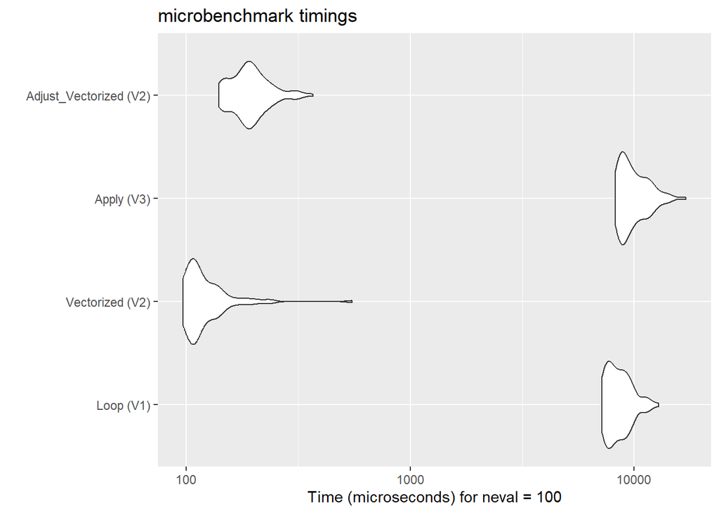

```r
print(autoplot(mb_low))
```

```r
mb_high <- microbenchmark(
  "Loop (V1)" = random_walk1(100000),
  "Vectorized (V2)" = random_walk2(100000),
  "Apply (V3)" = random_walk3(100000),
  "Adjust_Vectorized (V2)" = adjust_random_walk2(100000),
  times = 10
)
print("Performance for n = 100,000")
```

```
[1] "Performance for n = 100,000"
```

```r
print(mb_high)
```

```
Unit: milliseconds
                   expr      min        lq       mean     median        uq
              Loop (V1) 832.7963  845.8303  931.63493  923.30480 1016.4120
        Vectorized (V2)   9.7267    9.7928   11.23188   10.05210   10.2605
             Apply (V3) 944.3078 1031.3546 1200.18413 1134.35145 1213.8635
 Adjust_Vectorized (V2)  12.4581   14.2883   16.17075   14.65465   15.6671
       max neval
 1038.1620    10
   17.4764    10
 1906.1056    10
   26.4485    10
```

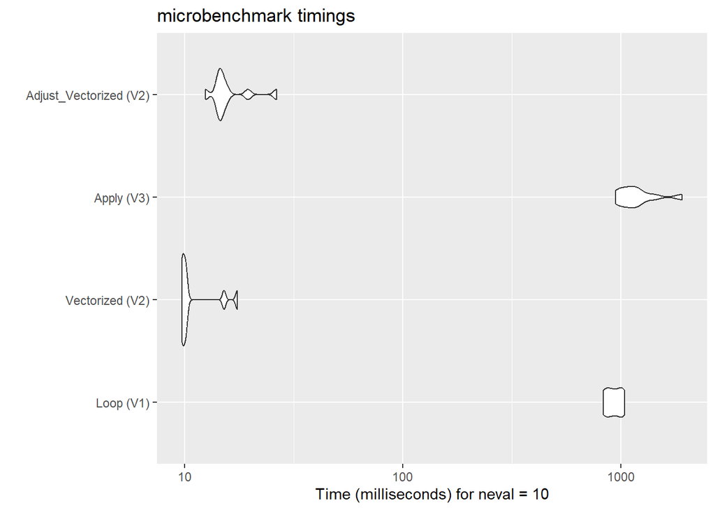

```r
print(autoplot(mb_high))
```

D

```r
#' V2 is the quickest, so I choose V2 here
monte_carlo_walk <- function(n, num_simulations = 100000) {
  results <- replicate(num_simulations, random_walk2(n))
  zero_count <- sum(results == 0)
  probability <- zero_count / num_simulations
  return(probability)
}
set.seed(42)
prob_10 <- monte_carlo_walk(10)
print(paste("Probability of ending at 0 with 10 steps:", prob_10))
```

```
[1] "Probability of ending at 0 with 10 steps: 0.13319"
```

```r
prob_100 <- monte_carlo_walk(100)
print(paste("Probability of ending at 0 with 100 steps:", prob_100))
```

```
[1] "Probability of ending at 0 with 100 steps: 0.02011"
```

```r
prob_1000 <- monte_carlo_walk(1000)
print(paste("Probability of ending at 0 with 1000 steps:", prob_1000))
```

```
[1] "Probability of ending at 0 with 1000 steps: 0.00556"
```

we can find that, with the increase of step numbers , the probability of 0 is becoming less.

## Problem 2

```r
#' @title Estimate Average Daily Cars via Monte Carlo Simulation
#' @description This script performs a Monte Carlo simulation to estimate the average
#' number of cars passing an intersection in a 24-hour period. It uses vectorized R functions to model different hourly traffic distributions without the use of loops, as specified by the problem.
#' @param num_simulations An integer specifying the number of days to simulate
#' @return A numeric value representing the estimated average number of cars per day, based on the simulation.
#' @examples
#' # Estimate with the default 100,000 simulations
#' estimate_daily_cars()
#' # Estimate with a smaller number of simulations for a quick check
#' estimate_daily_cars(num_simulations = 1000)
estimate_daily_cars <- function(num_simulations = 100000) {

  #'Step 1: Simulate car counts for each time block

  #' From midnight until 7 AM (7 hours): Poisson with mean 1
  cars_midnight_to_7am <- rpois(7 * num_simulations, lambda = 1)

  #' From 9am to 4pm (8 hours): Poisson with mean 8
  cars_9am_to_4pm <- rpois(8 * num_simulations, lambda = 8)

  #' From 6pm to 11pm (6 hours): Poisson with mean 12
  cars_6pm_to_11pm <- rpois(6 * num_simulations, lambda = 12)

  #' From 11pm to midnight (1 hour): Assumed to be Poisson with mean 1, consistent with the problem's 'midnight until 7 AM' assumption.
  cars_11pm_to_12am <- rpois(1 * num_simulations, lambda = 1)
  #' During rush hours (8am and 5pm - 2 hours): Normal with mean 60 and variance 12
  cars_rush_hour <- rnorm(2 * num_simulations, mean = 60, sd = sqrt(12))

  #' Step 2: Combine and calculate daily totals
  all_hourly_cars <- c(
    cars_midnight_to_7am,
    cars_9am_to_4pm,
    cars_6pm_to_11pm,
    cars_11pm_to_12am,
    cars_rush_hour
  )

  # Reshape the vector into a matrix where each row represents a full day.
  hourly_matrix <- matrix(
    all_hourly_cars,
    ncol = 24,
    byrow = TRUE
  )

  #' Use rowSums() to calculate the total number of cars for each simulated day.
  daily_totals <- rowSums(hourly_matrix)
  #' Step 3: Calculate and return the final average
  #' The estimated average is the mean of all the simulated daily totals.
  average_daily_cars <- mean(daily_totals)

  return(average_daily_cars)
}
  estimated_cars <- estimate_daily_cars()
  print(paste("Estimated average daily cars:", round(estimated_cars, 2)))
```

```
[1] "Estimated average daily cars: 263.97"
```

## Problem 3

A

```r
youtube <- read.csv('https://raw.githubusercontent.com/rfordatascience/tidytuesday/master/data/2021/2021-03-02/youtube.csv')
youtube_clean <- subset(youtube, select = -c(
  brand,
  superbowl_ads_dot_com_url,
  youtube_url,
  id,
  etag,
  published_at,
  title,
  description,
  thumbnail,
  channel_title
))

print("Original Dimensions:")
```

```
[1] "Original Dimensions:"
```

```r
print(dim(youtube))
```

```
[1] 247  25
```

```r
print("Dimensions after de-identification:")
```

```
[1] "Dimensions after de-identification:"
```

```r
print(dim(youtube_clean))
```

```
[1] 247  15
```

```r
print(head(youtube_clean))
```

```
  year funny show_product_quickly patriotic celebrity danger animals use_sex
1 2018 FALSE                FALSE     FALSE     FALSE  FALSE   FALSE   FALSE
2 2020  TRUE                 TRUE     FALSE      TRUE   TRUE   FALSE   FALSE
3 2006  TRUE                FALSE     FALSE     FALSE   TRUE    TRUE   FALSE
4 2018 FALSE                 TRUE     FALSE     FALSE  FALSE   FALSE   FALSE
5 2003  TRUE                 TRUE     FALSE     FALSE   TRUE    TRUE    TRUE
6 2020  TRUE                 TRUE     FALSE      TRUE   TRUE    TRUE   FALSE
           kind view_count like_count dislike_count favorite_count
1 youtube#video     173929       1233            38              0
2 youtube#video      47752        485            14              0
3 youtube#video     142310        129            15              0
4 youtube#video        198          2             0              0
5 youtube#video      13741         20             3              0
6 youtube#video      23636        115            11              0
  comment_count category_id
1            NA           1
2            14          27
3             9          17
4             0          22
5             2          24
6            13           1
```

B

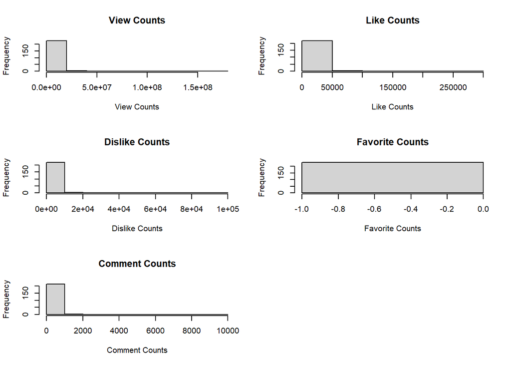

```r
library(ggplot2)

#' Set up the plotting grid
par(mfrow = c(3, 2))

#' Examine the distribution of each count variable
hist(youtube_clean$view_count, main = "View Counts", xlab = "View Counts")
hist(youtube_clean$like_count, main = "Like Counts", xlab = "Like Counts")
hist(youtube_clean$dislike_count, main = "Dislike Counts", xlab = "Dislike Counts")
hist(youtube_clean$favorite_count, main = "Favorite Counts", xlab = "Favorite Counts")
hist(youtube_clean$comment_count, main = "Comment Counts", xlab = "Comment Counts")
```

```r
#' favorite counts are different, have a look at it
zero_count <- sum(youtube_clean$favorite_count == 0, na.rm = TRUE)
total_count <- nrow(youtube_clean)
zero_percentage <- (zero_count / total_count) * 100

print(paste("number of 0:", zero_count))
```

```
[1] "number of 0: 231"
```

```r
print(paste("percentage of 0:", round(zero_percentage, 2), "%"))
```

```
[1] "percentage of 0: 93.52 %"
```

```r
print("different value:")
```

```
[1] "different value:"
```

```r
print(unique(youtube_clean$favorite_count))
```

```
[1]  0 NA
```

We can find that View counts ,Like counts,Dislike counts,Comment counts are all ii, they are Skewed to the right and can use a transformation prior to being used as the outcome in a linear regression model. But the favorite count is iii,the variable would not be appropriate to use as the outcome in a linear regression model because the values of this are all 0 and NA.

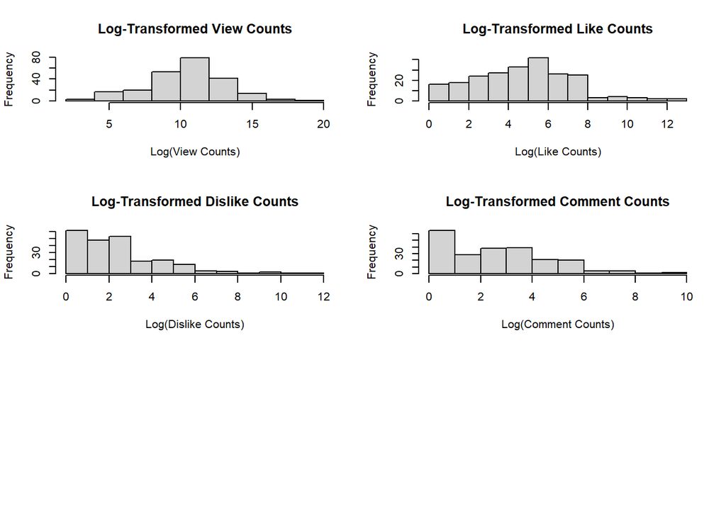

```r
youtube_transformed <- youtube_clean
youtube_transformed$log_views <- log(youtube_transformed$view_count + 1)
youtube_transformed$log_likes <- log(youtube_transformed$like_count + 1)
youtube_transformed$log_dislikes <- log(youtube_transformed$dislike_count + 1)
youtube_transformed$log_comments <- log(youtube_transformed$comment_count + 1)
par(mfrow = c(3, 2))
hist(youtube_transformed$log_views, main = "Log-Transformed View Counts", xlab = "Log(View Counts)")
hist(youtube_transformed$log_likes, main = "Log-Transformed Like Counts", xlab = "Log(Like Counts)")
hist(youtube_transformed$log_dislikes, main = "Log-Transformed Dislike Counts", xlab = "Log(Dislike Counts)")
hist(youtube_transformed$log_comments, main = "Log-Transformed Comment Counts", xlab = "Log(Comment Counts)")
```

C

```r
model_views <- lm(log_views ~ funny + show_product_quickly + patriotic + celebrity + danger + animals + use_sex + year, data = youtube_transformed)
model_likes <- lm(log_likes ~ funny + show_product_quickly + patriotic + celebrity + danger + animals + use_sex + year, data = youtube_transformed)
model_dislikes <- lm(log_dislikes ~ funny + show_product_quickly + patriotic + celebrity + danger + animals + use_sex + year, data = youtube_transformed)
model_comments <- lm(log_comments ~ funny + show_product_quickly + patriotic + celebrity + danger + animals + use_sex + year, data = youtube_transformed)
print("================== Summary for Log Views ==================")
```

```
[1] "================== Summary for Log Views =================="
```

```r
summary(model_views)
```

```
Call:
lm(formula = log_views ~ funny + show_product_quickly + patriotic +
    celebrity + danger + animals + use_sex + year, data = youtube_transformed)

Residuals:
    Min      1Q  Median      3Q     Max
-7.7742 -1.6152  0.1311  1.7036  8.4481

Coefficients:
                          Estimate Std. Error t value Pr(>|t|)
(Intercept)              -31.55016   71.00538  -0.444    0.657
funnyTRUE                  0.56492    0.46702   1.210    0.228
show_product_quicklyTRUE   0.21089    0.40530   0.520    0.603
patrioticTRUE              0.50699    0.53811   0.942    0.347
celebrityTRUE              0.03548    0.42228   0.084    0.933
dangerTRUE                 0.63131    0.41812   1.510    0.132
animalsTRUE               -0.31002    0.39348  -0.788    0.432
use_sexTRUE               -0.38671    0.44782  -0.864    0.389
year                       0.02053    0.03531   0.582    0.561

Residual standard error: 2.787 on 222 degrees of freedom
  (16 observations deleted due to missingness)
Multiple R-squared:  0.02694,   Adjusted R-squared:  -0.008122
F-statistic: 0.7684 on 8 and 222 DF,  p-value: 0.631
```

```r
print("================== Summary for Log Likes ==================")
```

```
[1] "================== Summary for Log Likes =================="
```

```r
summary(model_likes)
```

```
Call:
lm(formula = log_likes ~ funny + show_product_quickly + patriotic +
    celebrity + danger + animals + use_sex + year, data = youtube_transformed)

Residuals:
    Min      1Q  Median      3Q     Max
-5.2860 -1.6333  0.0868  1.4911  7.7431

Coefficients:
                           Estimate Std. Error t value Pr(>|t|)
(Intercept)              -150.51357   63.45723  -2.372   0.0186 *
funnyTRUE                   0.47476    0.41816   1.135   0.2575
show_product_quicklyTRUE    0.20017    0.36391   0.550   0.5828
patrioticTRUE               0.80689    0.49791   1.621   0.1066
celebrityTRUE               0.41283    0.38212   1.080   0.2812
dangerTRUE                  0.63895    0.37350   1.711   0.0886 .
animalsTRUE                -0.05944    0.35298  -0.168   0.8664
use_sexTRUE                -0.42952    0.40064  -1.072   0.2849
year                        0.07685    0.03155   2.436   0.0157 *
---
Signif. codes:  0 '***' 0.001 '**' 0.01 '*' 0.05 '.' 0.1 ' ' 1

Residual standard error: 2.467 on 216 degrees of freedom
  (22 observations deleted due to missingness)
Multiple R-squared:  0.07313,   Adjusted R-squared:  0.03881
F-statistic:  2.13 on 8 and 216 DF,  p-value: 0.0342
```

```r
print("================== Summary for Log Dislikes ==================")
```

```
[1] "================== Summary for Log Dislikes =================="
```

```r
summary(model_dislikes)
```

```
Call:
lm(formula = log_dislikes ~ funny + show_product_quickly + patriotic +
    celebrity + danger + animals + use_sex + year, data = youtube_transformed)

Residuals:
    Min      1Q  Median      3Q     Max
-4.0292 -1.3299 -0.3192  0.8986  8.7219

Coefficients:
                           Estimate Std. Error t value Pr(>|t|)
(Intercept)              -183.06813   53.34768  -3.432 0.000719 ***
funnyTRUE                   0.25949    0.35154   0.738 0.461224
show_product_quicklyTRUE    0.27511    0.30593   0.899 0.369515
patrioticTRUE               0.81407    0.41859   1.945 0.053095 .
celebrityTRUE              -0.20214    0.32125  -0.629 0.529852
dangerTRUE                  0.22184    0.31400   0.707 0.480630
animalsTRUE                -0.21192    0.29675  -0.714 0.475911
use_sexTRUE                -0.32980    0.33681  -0.979 0.328583
year                        0.09207    0.02653   3.471 0.000626 ***
---
Signif. codes:  0 '***' 0.001 '**' 0.01 '*' 0.05 '.' 0.1 ' ' 1

Residual standard error: 2.074 on 216 degrees of freedom
  (22 observations deleted due to missingness)
Multiple R-squared:  0.09753,   Adjusted R-squared:  0.06411
F-statistic: 2.918 on 8 and 216 DF,  p-value: 0.004115
```

```r
print("================== Summary for Log Comments ==================")
```

```
[1] "================== Summary for Log Comments =================="
```

```r
summary(model_comments)
```

```
Call:
lm(formula = log_comments ~ funny + show_product_quickly + patriotic +
    celebrity + danger + animals + use_sex + year, data = youtube_transformed)

Residuals:
    Min      1Q  Median      3Q     Max
-4.1372 -1.4665 -0.1427  1.4061  5.8468

Coefficients:
                          Estimate Std. Error t value Pr(>|t|)
(Intercept)              -99.09835   52.92351  -1.872   0.0625 .
funnyTRUE                  0.21954    0.34528   0.636   0.5256
show_product_quicklyTRUE   0.40939    0.30229   1.354   0.1771
patrioticTRUE              0.66698    0.39902   1.672   0.0961 .
celebrityTRUE              0.29767    0.31541   0.944   0.3464
dangerTRUE                 0.17784    0.31069   0.572   0.5677
animalsTRUE               -0.26802    0.29347  -0.913   0.3621
use_sexTRUE               -0.39323    0.33163  -1.186   0.2370
year                       0.05034    0.02632   1.913   0.0571 .
---
Signif. codes:  0 '***' 0.001 '**' 0.01 '*' 0.05 '.' 0.1 ' ' 1

Residual standard error: 2.039 on 213 degrees of freedom
  (25 observations deleted due to missingness)
Multiple R-squared:  0.06535,   Adjusted R-squared:  0.03025
F-statistic: 1.862 on 8 and 213 DF,  p-value: 0.06748
```

Overall, across the four models, Year was the only variable consistently found to have a significant positive effect on multiple outcomes (specifically, log_likes and log_dislikes). This suggests that, over time, both likes and dislikes for these ads have been increasing significantly.

As for the seven ad characteristics, their influence on view, like, dislike, and comment counts was largely not statistically significant. This could imply that other factors not included in our models, such as ad quality or marketing strategy, have a stronger impact on YouTube engagement metrics.

D

```r
#' a data frame without NA
model_data <- na.omit(data.frame(
  y = youtube_transformed$log_views,
  funny = youtube_transformed$funny,
  show_product_quickly = youtube_transformed$show_product_quickly,
  patriotic = youtube_transformed$patriotic,
  celebrity = youtube_transformed$celebrity,
  danger = youtube_transformed$danger,
  animals = youtube_transformed$animals,
  use_sex = youtube_transformed$use_sex,
  year = youtube_transformed$year
))
#'Step 1: Create the dependent variable vector (y)
y <- as.matrix(model_data$y)

#' Step 2: Create the design matrix (X)
X <- model.matrix(y ~ funny + show_product_quickly + patriotic + celebrity + danger + animals + use_sex + year, data = model_data)

#' Step 3: Manually calculate the regression coefficients (beta_hat_manual)
#' Formula: beta_hat = (X'X)^-1 * X'y
XtX <- t(X) %*% X
XtX_inv <- solve(XtX)
Xty <- t(X) %*% y
beta_hat_manual <- XtX_inv %*% Xty

#' Step 4: Use lm() to confirm the results
#' Fit the model using lm()
model_lm <- lm(log_views ~ funny + show_product_quickly + patriotic + celebrity + danger + animals + use_sex + year, data = youtube_transformed)

#' Get the coefficients from the lm() model
beta_hat_lm <- coef(model_lm)
print("Manually Calculated Coefficients (Manual Beta Hat):")
```

```
[1] "Manually Calculated Coefficients (Manual Beta Hat):"
```

```r
print(beta_hat_manual)
```

```
                                 [,1]
(Intercept)              -31.55015804
funnyTRUE                  0.56492445
show_product_quicklyTRUE   0.21088918
patrioticTRUE              0.50699051
celebrityTRUE              0.03547862
dangerTRUE                 0.63131085
animalsTRUE               -0.31001838
use_sexTRUE               -0.38670726
year                       0.02053399
```

```r
print("lm() Calculated Coefficients (lm() Beta Hat):")
```

```
[1] "lm() Calculated Coefficients (lm() Beta Hat):"
```

```r
print(beta_hat_lm)
```

```
             (Intercept)                funnyTRUE show_product_quicklyTRUE
            -31.55015804               0.56492445               0.21088918
           patrioticTRUE            celebrityTRUE               dangerTRUE
              0.50699051               0.03547862               0.63131085
             animalsTRUE              use_sexTRUE                     year
             -0.31001838              -0.38670726               0.02053399
```

```r
all_equal <- all.equal(as.vector(beta_hat_manual), as.vector(beta_hat_lm))
print("Are the manual and lm() results identical?")
```

```
[1] "Are the manual and lm() results identical?"
```

```r
print(all_equal)
```

```
[1] TRUE
```